# Final Project Pitch: Power Production Prediction

### Overview:

Predict a country’s renewable energy production based on historical weather data and forecasted weather conditions.

### Purpose:

Anticipate electricity production from renewable sources to facilitate better management of energy storage, import/export decisions, and prioritisation of green initiatives. This project aims to provide insights into optimising energy usage and promoting sustainable practices.

### Project Mindset:

As this is a very short project, the motto will be K.I.S.S - Keep It Simple Stupid, basic functionality will be achieved before introducing extra (optional) complexity. This will facilitate reinforcement learning of what is known and will build on that with wherever the team has interest to explore.

Complexity can be introduced in almost all stages, and will be flexible for team members to discuss and explore their interests.

## Methodology:

### Model Development:

1. Identify and optimise features for predicting total renewable energy production.
2. Explore sector-specific predictions for Solar, Wind, Hydro, Geothermal, etc. i.e. using a vectorised target
3. Optionally, match the country’s energy production with predicted residential consumption.

### Machine Learning Models:

1. Initially, focus on ML models (Random Forests and XGBoost).
2. Open to exploring RNN models in parallel for comparison.

### Front End - Design a user-friendly interface:

1. Select country.
2. Manually input weather conditions.
3. Output total renewable energy production.

### Extra Features:

1. Option to view sectored renewable energy production.
2. Option to choose a specific period for weather prediction through an API call.
3. Monitor and incorporate changes in renewable energy infrastructure.
4. Track installations or decommissioning of assets.
5. Explore data on current infrastructure and future plans.

## Data Sources:

1. IEA (International Energy Agency) - Historical weather, energy production, and energy end-use data.
2. OpenWeather - Future weather forecasting.
3. Additional sources for infrastructure data (if available).

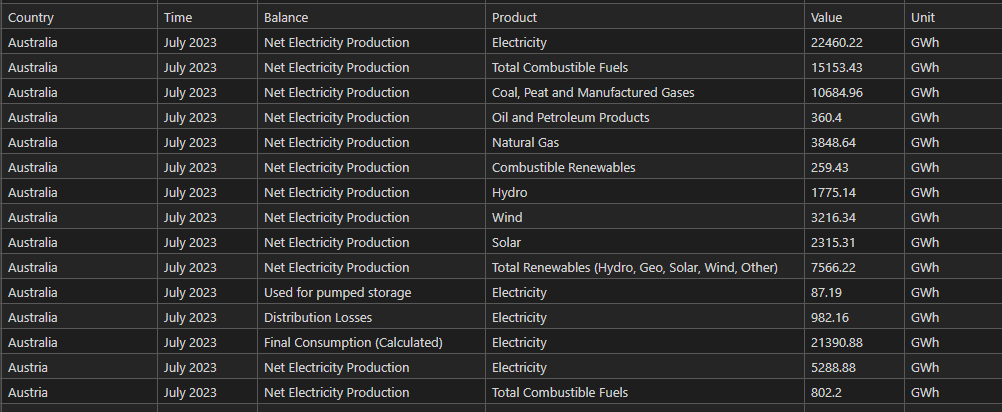

[figure not shown]

[figure not shown]

## Foreseeable Challenges:

1. Data Integration: Combine weather and energy output datasets effectively.
2. Country-Specific Capabilities: Account for variations in renewable energy capabilities across countries.
3. Precision Challenges: Acknowledge potential limitations in achieving precise predictions, especially in regions with limited capabilities.
4. Model Evaluation: Utilise MAE for error assessment, considering variations in capabilities and potential errors as part of the analysis.

## Next Steps:

1. Explore feature selection and optimization for accurate predictions.
2. Implement ML models (Random Forests, XGBoost) for initial analysis.
3. Develop the front-end interface for user interaction.
4. Address challenges and refine the model based on feedback and performance.

## Conclusion:

The Power Production Prediction project aims to contribute to sustainable energy practices by providing actionable insights into renewable energy production. Through data analysis, model development, and user-friendly interfaces, we seek to empower green initiatives and facilitate informed decision-making in the energy sector.